# Basic Probability

# Union of Events

The **union** of two events, $A$ and $B$, is the **event that at least one of them occurs**:
$$P(A \text{ or } B)
= P(A) + P(B) - P(A \text{ and } B)$$

If $A$ and $B$ are disjoint, then
$$P(A \text{ or } B) = P(A) + P(B)$$

$\star$ **Key Idea:** The probability of the union is the sum of individual probabilities minus their intersection (to avoid double-counting).

# Joint vs Disjoint Venn Diagram

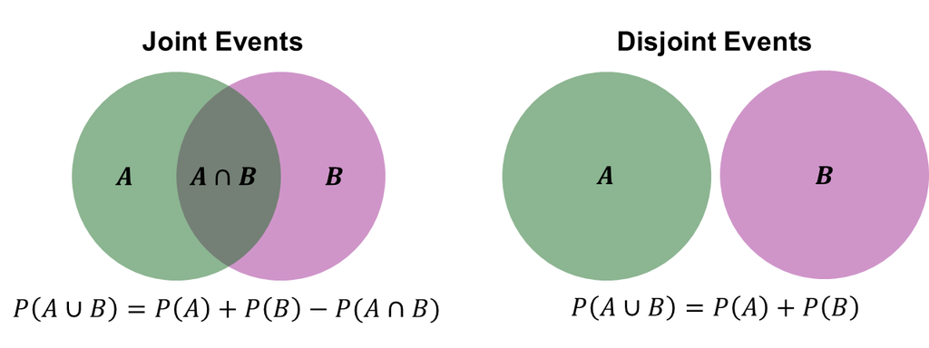

# Drawing Cards

Suppose we conduct an experiment of drawing specific characteristics of a card from a 52-card deck.

- Let $A$ be the event that we draw a Queen.
- Let $B$ be the event that we draw a Heart.
- Events $A$ and $B$ are joint.
  - $P(A \text{ and } B) = \frac{1}{52}$ (Queen of Hearts).
- We know that there are 4 Queens and 13 Hearts.
  - $P(A) = \frac{4}{52}$, $P(B) = \frac{13}{52}$, and
  - $P(A \text{ or } B) = P(A) + P(B) - P(A \text{ and } B) = \frac{4}{52} + \frac{13}{52} - \frac{1}{52} = \frac{16}{52}$

$\dagger$ Can you compute the probability of drawing a face card (Ace, Jack, Queen, King) or a Diamond?

# Dice Rolls

Suppose we conduct an experiment of rolling two six-sided dice and sum the outcomes.

$\dagger$ Can you compute the probability of rolling a sum of 1? What about a sum of 3?

# Summary of Basic Probability Rules

**Basic Rules**

| **Rule** | **Formula** |
| --- | --- |
| *Independence* | $P(A \text{ and } B) = P(A)P(B)$ |
| *Joint (Union)* | $P(A \text{ or } B) = P(A) + P(B) - P(A \text{ and } B)$ |
| *Disjoint* | $P(A \text{ and } B) = 0$ |
| *Complement* | If $P(A) + P(B) = 1$, then $1-P(A)=P(B)$. |

# Probability Axioms

| **Axiom** | **Statement** |
| --- | --- |
| $P(S) = 1$ | The sum of the probabilities for all outcomes in the sample space is equal to 1. |
| $P \in [0,1]$ | Probabilities are always positive and always between $0$ and $1$. |
| $P(A \text{ or } B) = P(A) + P(B)$ | If events A and B are disjoint (mutually exclusive), then their probabilities can be added. |

# Interpreting Probability

**Frequentist probability** refers to the interpretation of probability based on the long-run frequency of an event occurring in repeated trials or experiments.

**Coin Flipping Example**

Suppose we conduct an experiment where we repeatedly flip a fair coin ($P(H) = 0.50$), tracking the cumulative count of Heads and its proportion after each flip.

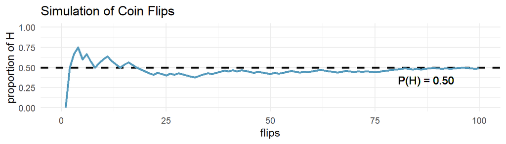

$\star$ **Key Idea:** As the number of flips (samples) increases the proportion of H gets closer and closer to the true proportion of H, which is $P(H)=0.50$.

# Activity: Taking Samples from Dice Rolls

1. Make sure you have a copy of the *W 2/19 Worksheet*. This will be handed out physically and it is also digitally available on Moodle.
2. Work on your worksheet by yourself for 10 minutes. Please read the instructions carefully. Ask questions if anything need clarifications.
3. Get together with another student.
4. Discuss your results.
5. Submit your worksheet on Moodle as a `.pdf` file.

# References

Diez, D. M., Barr, C. D., & Çetinkaya-Rundel, M. (2012). *OpenIntro statistics* (4th ed.). OpenIntro. https://www.openintro.org/book/os/